# Graph 1

These graphs show Google Trend values for two keyword search terms over time. They contain data for the District of Columbia metropolitan statistical area (MSA) and the United States as a whole. These graphs are illustrative of the potential of Google Trend data to provide insights on financial stress.

The data look at “food bank” and “payday loan” keyword searches for the past five years. This time period includes a recent exogenous shock: the federal shutdown. This event was reported to have significant financial impact on workers in the District of Columbia, causing them to have to visit food banks or seek costly loans.

```
Ignoring unknown parameters: model
```

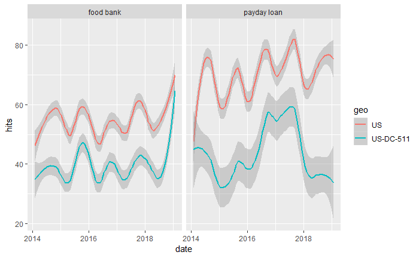

```r
ggplot(combined, aes(date, hits, group = geo, color = geo)) +
  geom_smooth(model = loess, span = .3) +
  facet_wrap(~keyword)
```

The data show that these two searchs are less common in Washington DC than in the rest of the United States generally. It also shows that they generally move cyclically. Searches for food banks in the US and DC tend to spike during the holiday season. Note the relative spike in food bank searches during the goverment shutdown (December 2018/January 2019).

Payday loans follow a similar pattern in the United States but not in Washington D.C., where there is a cluster of increased activity in the fourth quarter of 2016 and the start of 2017. This was also a period of significant labor market activity in Washington, D.C. as the presidency changed parties. There was, however, no apparent spike in payday loan searches during the shutdown.